# An introduction to GLMMs

Adapted by M. Pinsky from Zuur et al. 2009 Ch. 21 and the DHARMa tutorial

3/30/2021

## Introduction

Predicting the spatial distribution of wildlife populations is an important component of the development of management strategies for their conservation. Landscape structure and composition are important determinants of where species occur and the viability of their populations. In this exercise, we will model the impact of landscape pattern on the distribution of koalas (*Phascolarctos cinereus*) in a landscape in eastern Australia.

We will use generalised linear mixed effects models (GLMM) to model the distribution of koalas using data on their presence and absence at sites located across the study area. We also take a multi-scale approach in the sense that our explanatory variables will be landscape characteristics measured at different landscape extents. The analysis concentrates on dealing with collinearity and spatial auto-correlation for these types of landscape models.

## Data

The data presented are based on surveys that were conducted to determine koala presence or absence at 300 locations in Noosa. Using a form of stratified random sampling, 100 sites were first located across the Noosa LGA. Then, within each site, three subsites were located 100 m apart. At each subsite, the presence or absence of koalas was then determined using standardised searches for koala faecal pellets around the bases of trees. Previous work has identified the koala’s preferred tree species in Noosa and these have been classified into primary, secondary, and supplementary species. At each subsite, the percentage of trees that were primary and secondary species was recorded. Finally, the distribution of koala habitat (classified into highly suitable, suitable, marginal, and unsuitable habitat) was mapped.

The data on the presence/absence of koalas will be the response variable for our analysis, while the data on preferred tree species and habitat will form the basis of the explanatory variables.

The data frame contains a row for each subsite. The columns:

- `site`: site ID
- `subsite`: subsite ID numbers
- `easting`: eastings of the location of each subsite (in AMG ADG 1966 coordinates)
- `northing`: northings
- `presence`: whether koala pellets were found at the subsite (= 1) or not found at the subsite (= 0)
- `pprim_ssite`: %trees in each subsite that are primary tree species
- `psec_ssite`: %trees in each subsite that are secondary tree species
- `pdens_1km`: density of habitat patches (patches/100 ha), consisting of highly suitable plus suitable plus marginal habitat, in the landscape within 1 km of each subsite

```r
koalas <- readRDS(url('https://github.com/aeda2021/2021_master/raw/main/raw-data/koalas.rds'))
```

## Data exploration

Two important issues to consider before building regression models of species’ distributions are whether there is high collinearity between the explanatory variables and whether spatial auto-correlation between data points is likely to be an important factor. High collinearity can result in coefficient estimates that are difficult to interpret as independent effects and/or have high standard errors. Positive spatial auto-correlation violates the usual assumption of independence between data points and leads to the underestimation of standard errors, and elevated type I errors, if not accounted for. Collinearity between explanatory variables and spatial auto-correlation are commonly encountered when using observational data to construct regression models of species’ distributions. For both these issues, we examine whether they are likely to be a problem for the analysis of our dataset and then discuss how they can be addressed.

### Plots

Let’s start by making some plots of the response variable vs. each of the explanatory variables. It’s also helpful to make a map (plot response as dot color vs. northing and easting)

```r
library(tidyverse)
```

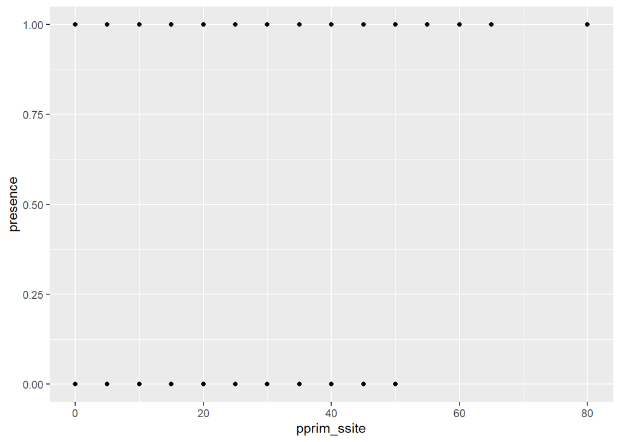

```r
ggplot(koalas, aes(x=pprim_ssite, y=presence)) +
    geom_point()
```

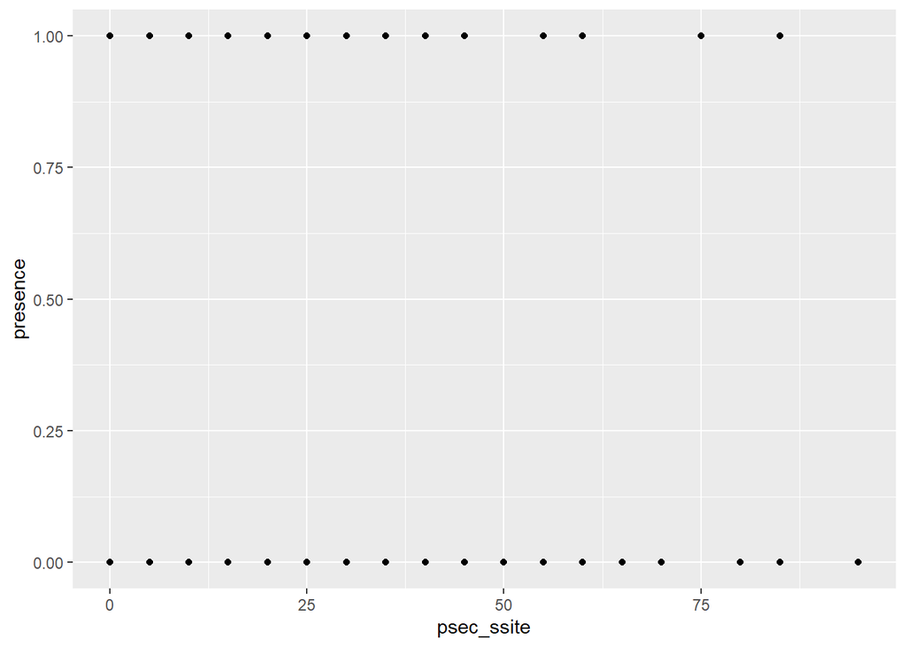

```r
ggplot(koalas, aes(x=psec_ssite, y=presence)) +
    geom_point()
```

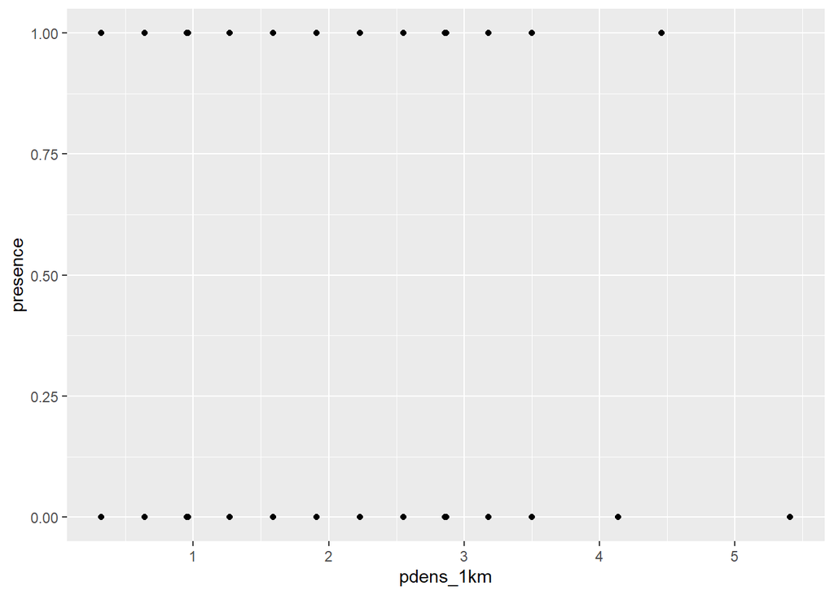

```r
ggplot(koalas, aes(x=pdens_1km, y=presence)) +
    geom_point()
```

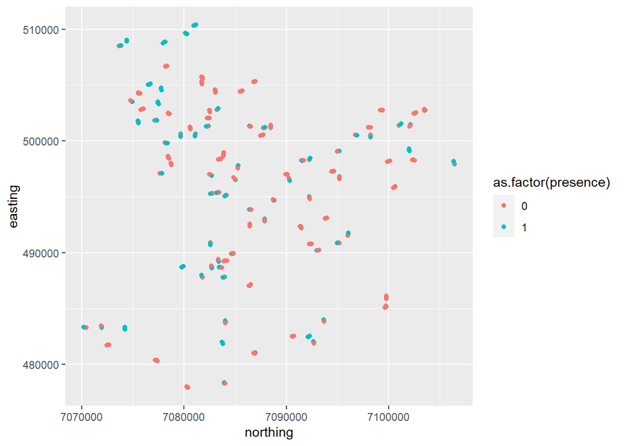

```r
ggplot(koalas, aes(x=northing, y=easting, color=as.factor(presence))) +
    geom_point()
```

### Evaluate colinearity

A simple first step for identifying collinearity is to look at the pairwise correlations between explanatory variables. We’ll use the Spearman rank correlation coefficient, rather than the Pearson correlation coefficient because the Spearman rank correlation makes no assumptions about linearity in the relationship between the two variables. A rough guideline is that correlations between pairs of variables with magnitudes greater than ±0.5 indicate high collinearity.

There are several strategies that we could use to deal with collinearity found between the explanatory variables. These include (i) simply removing one or more variables so that the remaining variables are not highly correlated, (ii) using linear combinations of the variables rather than the variables directly in the model, or (iii) using biased estimation procedures such as principal components regression or ridge regression. The first two are most straightforward.

The explanatory variables are in columns 6:8, so an easy approach use to use `pairs()` and `cor(..., method = 'spearman')` on `koalas[, 6:8]`.

Please use the code block below.

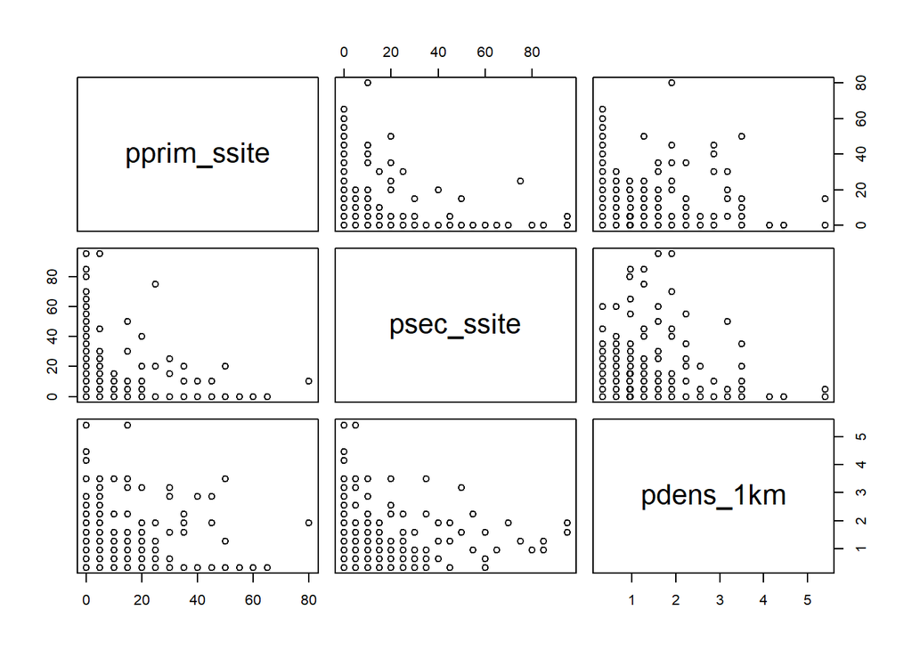

```r
pairs(koalas[,6:8])
```

```r
cor(koalas[,6:8], method='spearman')
```

```
##             pprim_ssite psec_ssite   pdens_1km
## pprim_ssite  1.00000000 -0.1912080 -0.01711065
## psec_ssite  -0.19120803  1.0000000  0.12294654
## pdens_1km   -0.01711065  0.1229465  1.00000000
```

#### Q1: Do you see signs of colinearity that concern you? If so, which ones?

No, I do not see any signs of colinearity that concern me. The magnitudes are all low and well below 0.5.

## Evaluate spatial autocorrelation

There are two reasons for expecting spatial auto-correlation in the presence/absence data. First, spatial auto-correlation at the site-scale may occur because the distances between the subsites within individual sites are small relative to the size of koala home ranges. Average koala home range sizes in similar east coast habitats have been estimated at between 10–25 ha for females and 20–90 ha for males. Therefore, the occurrences of koalas at subsites within an individual site will tend to be correlated because they would often have been located within the same koala’s home range.

Second, spatial auto-correlation at broader scales may occur due to spatially constrained dispersal of koalas from their natal home ranges. Koala dispersal distances in nearby regions have been recorded to be around 3–4 km, but can be as high as 10 km. So, dispersal distances are substantially smaller than the spatial extent of the study area, and this could also lead to spatial auto-correlation between sites. We could also see spatial auto-correlation in the presence/absence data if the underlying spatial pattern of habitat is spatially auto-correlated. However, we would expect our explanatory variables to account for most of the spatial auto-correlation from this source once the regression model is fitted to the data and is therefore considered to be of less concern.

One way to assess the extent of spatial auto-correlation is to look at correlograms of the data. Correlograms are graphical representations of the spatial correlation between locations at a range of lag distances. Positive spatial correlation indicates that spatial autocorrelation between data points may be a problem. Negative spatial correlation may also indicate a problem, but this is fairly unusual in this kind of data; so we are mainly concerned with positive correlations. We use a spline correlogram to investigate auto-correlation in the presence/absence data. The spline correlogram that we use is essentially a correlogram that is smoothed using a spline function.

We will first look at spatial auto-correlation in the raw data. However, we are predominantly interested in whether there is any spatial auto-correlation in model residuals once any spatial auto-correlation explained by the explanatory variables has been accounted for.

A spline correlogram of the raw presence/absence data can be plotted using the code below. The `spline.correlog()` function does 1000 bootstraps to calculate 95% confidence intervals up to a maximum lag distance of 10 km and may take a few minutes to run.

```r
correlog <- spline.correlog(x = koalas$easting,
                            y = koalas$northing,
                            z = koalas$presence,
                            xmax = 10000)
```

```
## 100  of  1000
200  of  1000
300  of  1000
400  of  1000
500  of  1000
600  of  1000
700  of  1000
800  of  1000
900  of  1000
1000  of  1000
```

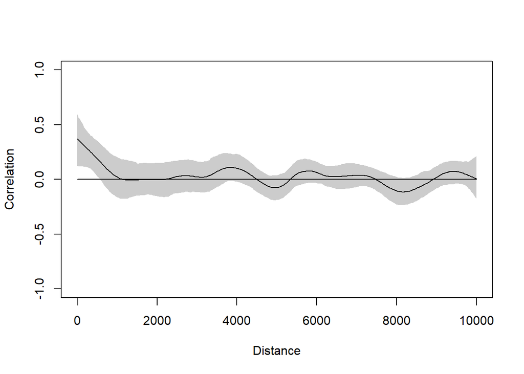

```r
plot(correlog)
```

## Standardize the explanatory variables

Before fitting models to the data, the explanatory variables should be standardized so that they each have a mean of zero and standard deviation of one. This helps to improve convergence of the fitting algorithm and puts the estimated coefficients on the same scale, allowing effect sizes to be more easily compared. We can standardize the explanatory variables by applying a function to each of the columns with explanatory variables:

```r
koalas_st <- cbind(koalas[, 1:5],
                   apply(X = koalas[, 6:ncol(koalas)],
                         MARGIN = 2,
                         FUN = function(x){(x - mean(x)) / sd(x)}
                         )
                   )
```

## Fit a first model (GLM)

Our response variable is presence/absence, and so it is not going to have nice Gaussian distribution. Please choose a more appropriate error distribution and fit a `glm()` with presence as the response variable and `pprim_ssite`, `psec_ssite`, and `pdens_1km` as the explanatory variables. Use `koalas_st` as your data source since it has the standardized variables. Save your model in `mod_glm` so that it works with some later code we’ll use.

```r
mod_glm <- glm(presence ~ pprim_ssite + psec_ssite + pdens_1km, family = 'binomial', data = koalas_st)
```

Just for good measure, use `summary()` to take a quick look:

```r
summary(mod_glm)
```

```
##
## Call:
## glm(formula = presence ~ pprim_ssite + psec_ssite + pdens_1km,
##     family = "binomial", data = koalas_st)
##
## Deviance Residuals:
##     Min       1Q   Median       3Q      Max
## -1.6018  -0.9151  -0.8527   1.3675   1.5563
##
## Coefficients:
##              Estimate Std. Error z value Pr(>|z|)
## (Intercept) -0.498530   0.121981  -4.087 4.37e-05 ***
## pprim_ssite  0.468638   0.130019   3.604 0.000313 ***
## psec_ssite   0.073048   0.121909   0.599 0.549037
## pdens_1km   -0.007958   0.122335  -0.065 0.948136
## ---
## Signif. codes:  0 '***' 0.001 '**' 0.01 '*' 0.05 '.' 0.1 ' ' 1
##
## (Dispersion parameter for binomial family taken to be 1)
##
##     Null deviance: 398.44  on 299  degrees of freedom
## Residual deviance: 383.96  on 296  degrees of freedom
## AIC: 391.96
##
## Number of Fisher Scoring iterations: 4
```

### Evaluate the model

How well does our model fit? Evaluating GLM(M)s can be hard, let’s look using the DHARMa package. As you read, the basic steps are

- Simulate new data from the fitted model for each observation.
- For each observation, calculate the empirical cumulative density function for the simulated observations, which describes the possible values (and their probability) at the predictor combination of the observed value, assuming the fitted model is correct.
- The residual is then defined as the value of the empirical density function at the value of the observed data, so a residual of 0 means that all simulated values are larger than the observed value, and a residual of 0.5 means half of the simulated values are larger than the observed value.

If the observed data were created from the same data-generating process that we simulate from, all values of the cumulative distribution should appear with equal probability. That means we expect the distribution of the residuals to be flat, regardless of the model structure (Poisson, binomial, random effects and so on).

First step is to simulate the randomized quantile residuals. Default is 250 simulations.

```r
res_glm <- simulateResiduals(fittedModel = mod_glm, plot = F)
```

Then plot them.

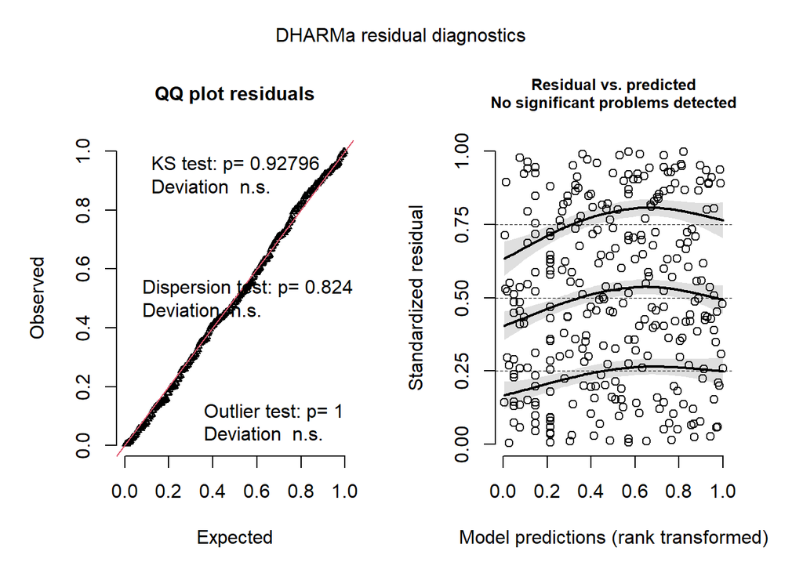

```r
plot(res_glm)
```

On the left is a qq-plot to detect overall deviations from the expected distribution, by default with added tests for correct distribution (KS test), dispersion and outliers. We want the residuals (black dots) to line up on the red line for the expected distribution. The DHARMa tutorial section on “Recognizing over/underdispersion” is good for interpreting deviations from this.

On the right panel is a plot of the residuals against the predicted value. Simulation outliers are highlighted as red stars. These points should be carefully interpreted, because we actually don’t know “how much” these values deviate from the model expectation. Note that outliers in DHARMa are values that are by default defined as values outside the simulation envelope, not in terms of a particular quantile. Note also that the probability of an outlier depends on the number of simulations, so whether the existence of outliers is a reason for concern depends also on the number of simulations (n=250 above).

To provide a visual aid in detecting deviations from uniformity in y-direction, the plot function calculates a quantile regression, which compares the empirical 0.25, 0.5 and 0.75 quantiles in the y-direction (solid lines) with the theoretical 0.25, 0.5 and 0.75 quantiles (dashed black line), and provides a p-value for the deviation from the expected quantile. The significance of the deviation to the expected quantiles is tested and displayed visually.

#### Q3: Evaluate the QQ plot and the residuals vs. predicted plots. If you see any concerns, please describe them.

The QQ plot looks good; the black dots follow the red line closely. The residual vs. predicted plots also look good, they are equally distributed, and there are not any outliers.

### Evaluate spatial auto-correlation in the GLM

We were concerned about spatial auto-correlation in our raw data, so let’s see if including the explanatory variables solved this. Use the same code that you used earlier for the spline correlogram, but now use `resid(mod_glm)` as the z axis.

```r
correlog2 <- spline.correlog(x = koalas$easting,
                            y = koalas$northing,
                            z = resid(mod_glm),
                            xmax = 10000)
```

```
## 100  of  1000
200  of  1000
300  of  1000
400  of  1000
500  of  1000
600  of  1000
700  of  1000
800  of  1000
900  of  1000
1000  of  1000
```

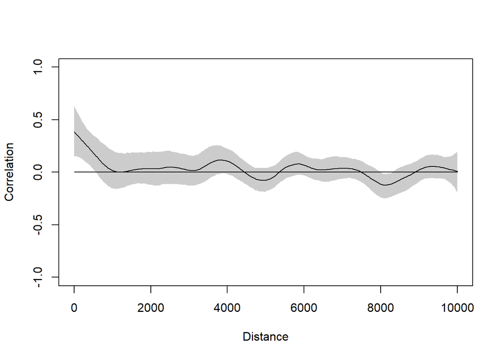

```r
plot(correlog2)
```

## Fit a GLMM

As you learned in the reading, GLMMs are useful when data are hierarchically structured in some way. They account for dependencies within hierarchical groups through the introduction of random-effects. In this study, the data are hierarchically structured in the sense that subsites are nested within sites, and we want to use mixed effects models to account for the spatial dependencies within sites. A suitable mixed effects model for these purposes can be constructed by introducing a random-effect for site into the standard logistic regression model.

As you also read (e.g., Ben Bolker’s FAQ), GLMMs are not simple to fit or interpret. The methods continue to evolve. Here, we will use the glmmTMB package developed by Ben Bolker. As a note, it also has some nice features for considering zero-inflated data and heteroscedasticity that we won’t get into today.

The syntax for glmmTMB is like `lmer()` in lme4 and like `glm()`, which is nice. See `?glmmTMB` for more information.

```
model <- glmmTMB(response ~ explanantoryvars + (1|random), data=mydata, family=family) # a random intercept model
model <- glmmTMB(response ~ explanantoryvars + (slope|random), data=mydata, family=family) # a random intercept and slope model
```

Here, we’ll use `site` as a random effect to help account for the spatial auto-correlation and pseudoreplication at that scale.

In the code block below, fit a GLMM using `glmmTMB()` with `pprim_ssite`, `psec_ssite`, and `pdens_1km` as your explanatory variables (like your GLM) and `site` as a random intercept. Make sure to pick a family that makes sense for these data. Use `koalas_st` as your data source and save to `mod_glmm`.

```r
mod_glmm <- glmmTMB(presence ~ pprim_ssite + psec_ssite + pdens_1km + (1|site), family = 'binomial', data = koalas_st)
```

Take a look with `summary()` on your GLMM.

```r
summary(mod_glmm)
```

```
##  Family: binomial  ( logit )
## Formula:          presence ~ pprim_ssite + psec_ssite + pdens_1km + (1 | site)
## Data: koalas_st
##
##      AIC      BIC   logLik deviance df.resid
##    369.7    388.2   -179.9    359.7      295
##
## Random effects:
##
## Conditional model:
##  Groups Name        Variance Std.Dev.
##  site   (Intercept) 2.729    1.652
## Number of obs: 300, groups:  site, 100
##
## Conditional model:
##              Estimate Std. Error z value Pr(>|z|)
## (Intercept) -0.761683   0.242537  -3.140 0.001687 **
## pprim_ssite  0.833103   0.230271   3.618 0.000297 ***
## psec_ssite   0.197584   0.198068   0.998 0.318494
## pdens_1km   -0.009749   0.211130  -0.046 0.963172
## ---
## Signif. codes:  0 '***' 0.001 '**' 0.01 '*' 0.05 '.' 0.1 ' ' 1
```

### Evaluate the model

Go ahead and evaluate your GLMM using

- DHARMa simulated residuals and standard plots
- a spatial correlogram of the residuals

as you did for the GLM.

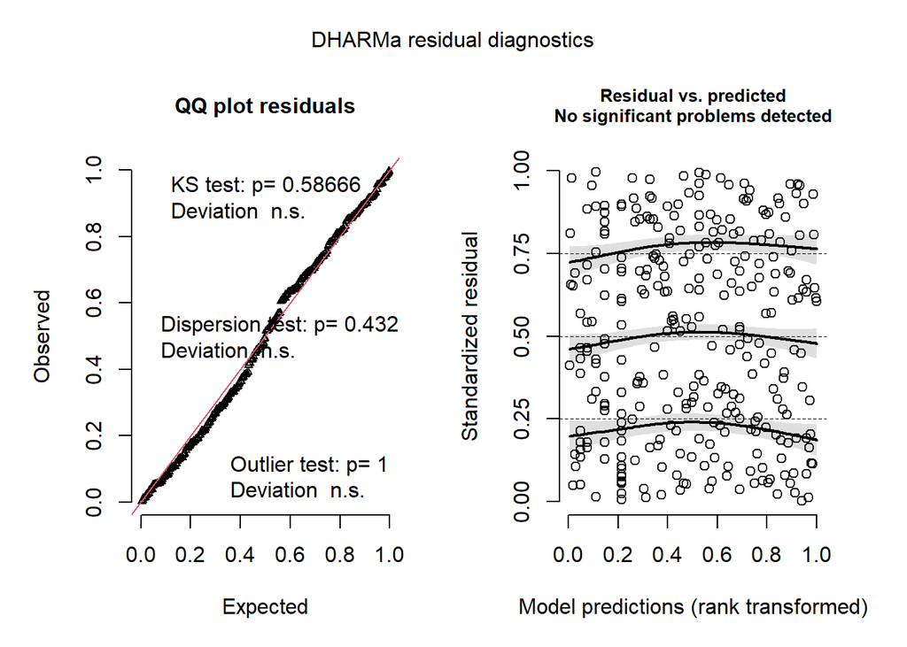

```r
res_glmm <- simulateResiduals(fittedModel = mod_glmm, plot = F)
plot(res_glmm)
```

```r
correlog_glmm <- spline.correlog(x = koalas$easting,
                            y = koalas$northing,
                            z = resid(mod_glmm),
                            xmax = 10000)
```

```
## 100  of  1000
200  of  1000
300  of  1000
400  of  1000
500  of  1000
600  of  1000
700  of  1000
800  of  1000
900  of  1000
1000  of  1000
```

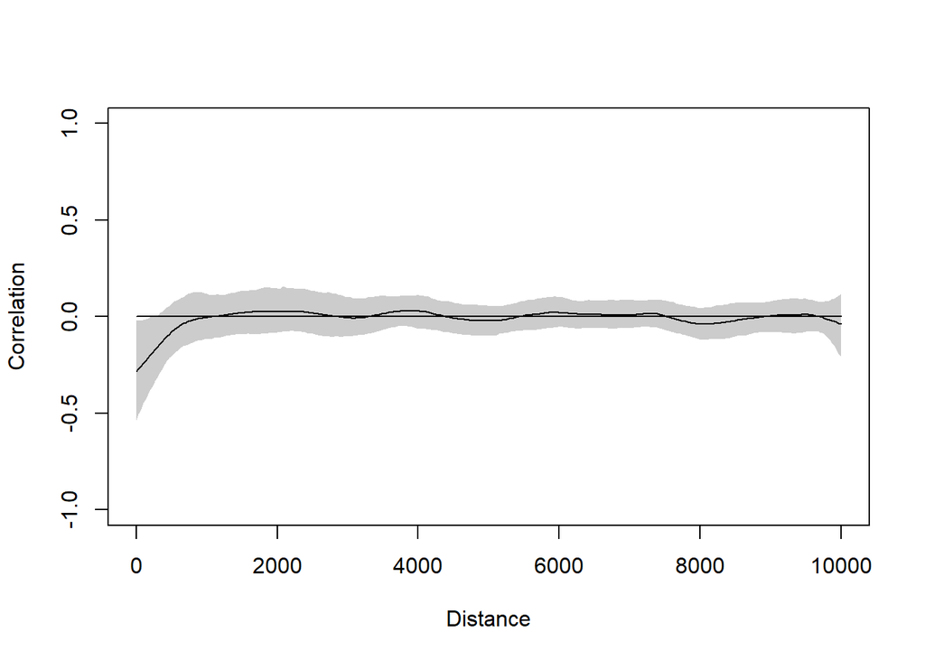

```r
plot(correlog_glmm)
```

It is also good practice to plot the residuals against each of the explanatory variables. You can do this in DHARMa with the syntax

```
plotResiduals(simulationOutput, yourData$variable)
```

Go ahead and do this for the three explanatory variables below:

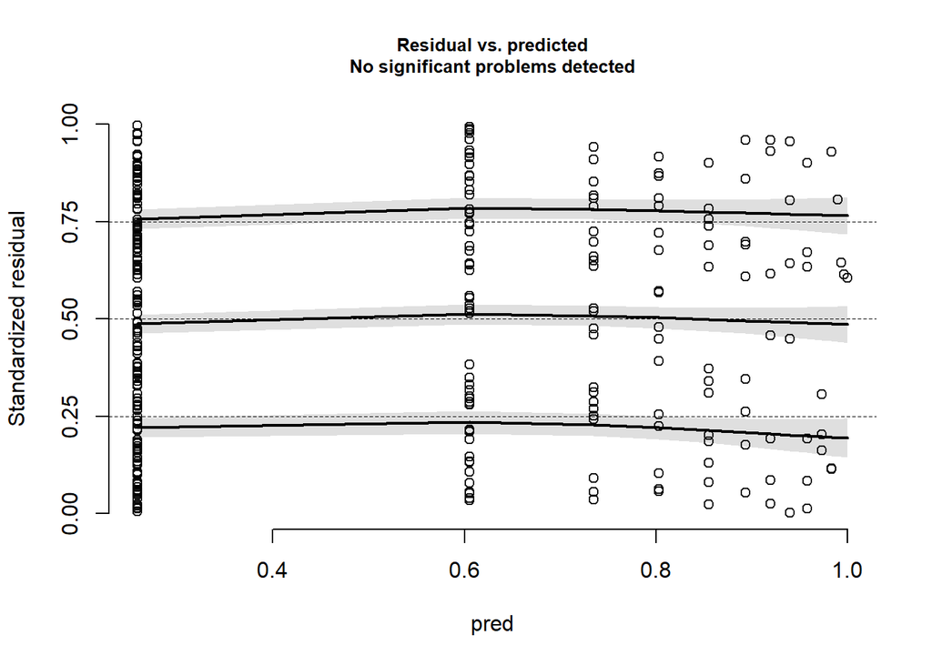

```r
plotResiduals(res_glmm, koalas_st$pprim_ssite)
```

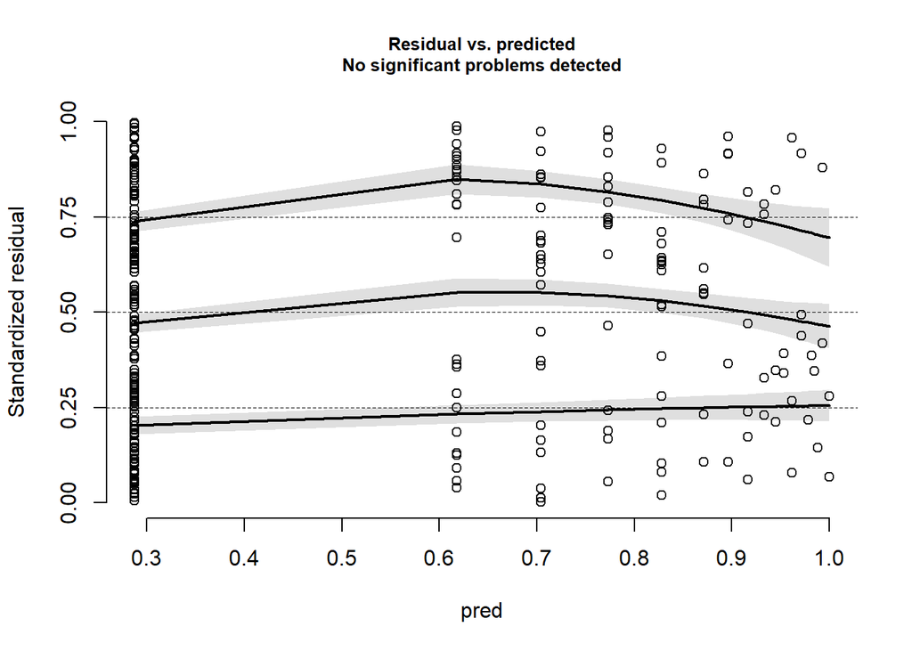

```r
plotResiduals(res_glmm, koalas_st$psec_ssite)
```

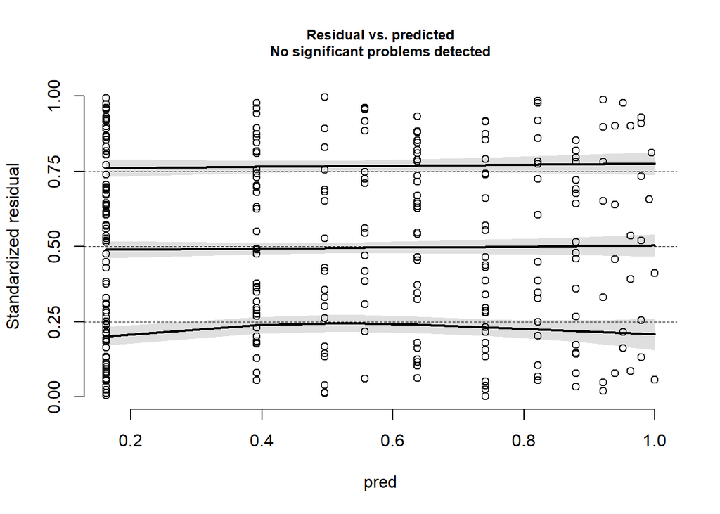

```r
plotResiduals(res_glmm, koalas_st$pdens_1km)
```

#### Q5: Evaluate the QQ plot, the residuals vs. predicted plot, the spline correlogram, and the residuals vs. explantory variables. Does anything concern you?

The QQ plot looks good, and the points follow the red line nicely. The residuals vs. predicted plot has points spread out evenly, and looks appropriate. The correlogram looks better than before with only a glm. Each residuals vs. explanatory plots also appear to be evenly distributed and look okay.

## Fit an alternative GLMM

We can also compare among GLMMs with AIC. Fit a new GLMM like your first but with only site-scale variables in it (only `pprim_ssite` and `psec_ssite`).

```r
mod_glmm2 <- glmmTMB(presence ~ pprim_ssite + psec_ssite + (1|site), family = 'binomial', data = koalas_st)
```

### Compare the models

Now compare your models. You can use the syntax

```
AIC(model1, model2)
```

```r
AIC(mod_glmm, mod_glmm2)
```

```
##           df      AIC
## mod_glmm   5 369.7018
## mod_glmm2  4 367.7040
```

When you’re done, click “Knit” above to turn this into a Github document that will display nicely on Github. It will also create a sub-directory with the image files in it. Commit everything to your Git repo, and push to Github. **Congratulations!**